# Problems Statement - Clustering

## Description

- AllLife Bank wants to focus on its credit card customer base in the next financial year. They have been advised by their marketing research team, that the penetration in the market can be improved. Based on this input, the Marketing team proposes to run personalized campaigns to target new customers as well as upsell to existing customers. Another insight from the market research was that the customers perceive the support services of the back poorly. Based on this, the Operations team wants to upgrade the service delivery model, to ensure that customer queries are resolved faster. Head of Marketing and Head of Delivery both decide to reach out to the Data Science team for help

### Objective

-To identify different segments in the existing customer, based on their spending patterns as well as past interaction with the bank, using clustering algorithms, and provide recommendations to the bank on how to better market to and service these customers.

- Dataset: Credit+Card+Customer+Data.xlsxDownload Credit+Card+Customer+Data.xlsx

### Data Description

- The data provided is of various customers of a bank and their financial attributes like credit limit, the total number of credit cards the customer has, and different channels through which customers have contacted the bank for any queries (including visiting the bank, online and through a call center).

### Data Dictionary

- Sl_No: Primary key of the records
- Customer Key: Customer identification number
- Average Credit Limit: Average credit limit of each customer for all credit cards
- Total credit cards: Total number of credit cards possessed by the customer
- Total visits bank: Total number of visits that customer made (yearly) personally to the bank
- Total visits online: Total number of visits or online logins made by the customer (yearly)
- Total calls made: Total number of calls made by the customer to the bank or its customer service department (yearly)

```python
# Libraries to help load and manipulate the data

import numpy as np
import pandas as pd
import matplotlib.pyplot as plt
import seaborn as sns
sns.set_theme()
```

```python
# To load the data


url = r"C:\Users\Admin\Desktop\Credit+Card+Customer+Data.xlsx"
data = pd.read_excel(url)

# To check the first 5 rows in the data

data.head()
```

|  | Sl_No | Customer Key | Avg_Credit_Limit | Total_Credit_Cards | Total_visits_bank | Total_visits_online | Total_calls_made |
| --- | --- | --- | --- | --- | --- | --- | --- |
| 0 | 1 | 87073 | 100000 | 2 | 1 | 1 | 0 |
| 1 | 2 | 38414 | 50000 | 3 | 0 | 10 | 9 |
| 2 | 3 | 17341 | 50000 | 7 | 1 | 3 | 4 |
| 3 | 4 | 40496 | 30000 | 5 | 1 | 1 | 4 |
| 4 | 5 | 47437 | 100000 | 6 | 0 | 12 | 3 |

```python
# To randomly check any 10 rows in the data

data.sample(10, random_state =0)
```

|  | Sl_No | Customer Key | Avg_Credit_Limit | Total_Credit_Cards | Total_visits_bank | Total_visits_online | Total_calls_made |
| --- | --- | --- | --- | --- | --- | --- | --- |
| 541 | 542 | 50706 | 60000 | 7 | 5 | 2 | 2 |
| 103 | 104 | 73007 | 13000 | 1 | 0 | 3 | 7 |
| 14 | 15 | 68517 | 6000 | 2 | 2 | 4 | 6 |
| 526 | 527 | 58708 | 29000 | 4 | 2 | 2 | 3 |
| 298 | 299 | 38994 | 12000 | 6 | 5 | 0 | 2 |
| 162 | 163 | 80457 | 8000 | 2 | 0 | 3 | 4 |
| 592 | 593 | 99473 | 54000 | 5 | 4 | 2 | 1 |
| 474 | 475 | 29919 | 38000 | 4 | 3 | 1 | 4 |
| 547 | 548 | 38125 | 26000 | 4 | 5 | 2 | 4 |
| 620 | 621 | 32107 | 108000 | 10 | 0 | 15 | 1 |

```python
# To check the dimension of the data

data.shape
```

```
(660, 7)
```

- There are 660 rows and 7 columns in the data

```python
# To check the structure of the data

data.info()
```

```
<class 'pandas.core.frame.DataFrame'>
RangeIndex: 660 entries, 0 to 659
Data columns (total 7 columns):
 #   Column               Non-Null Count  Dtype
---  ------               --------------  -----
 0   Sl_No                660 non-null    int64
 1   Customer Key         660 non-null    int64
 2   Avg_Credit_Limit     660 non-null    int64
 3   Total_Credit_Cards   660 non-null    int64
 4   Total_visits_bank    660 non-null    int64
 5   Total_visits_online  660 non-null    int64
 6   Total_calls_made     660 non-null    int64
dtypes: int64(7)
memory usage: 36.2 KB
```

**Observations**

- There are 660 rows and 7 columns in the data
- All columns are numerical
- The data occupies 36.2KB memory space.

```python
# To check the descriptive statistics of the data

data.describe()
```

|  | Sl_No | Customer Key | Avg_Credit_Limit | Total_Credit_Cards | Total_visits_bank | Total_visits_online | Total_calls_made |
| --- | --- | --- | --- | --- | --- | --- | --- |
| count | 660.000000 | 660.000000 | 660.000000 | 660.000000 | 660.000000 | 660.000000 | 660.000000 |
| mean | 330.500000 | 55141.443939 | 34574.242424 | 4.706061 | 2.403030 | 2.606061 | 3.583333 |
| std | 190.669872 | 25627.772200 | 37625.487804 | 2.167835 | 1.631813 | 2.935724 | 2.865317 |
| min | 1.000000 | 11265.000000 | 3000.000000 | 1.000000 | 0.000000 | 0.000000 | 0.000000 |
| 25% | 165.750000 | 33825.250000 | 10000.000000 | 3.000000 | 1.000000 | 1.000000 | 1.000000 |
| 50% | 330.500000 | 53874.500000 | 18000.000000 | 5.000000 | 2.000000 | 2.000000 | 3.000000 |
| 75% | 495.250000 | 77202.500000 | 48000.000000 | 6.000000 | 4.000000 | 4.000000 | 5.000000 |
| max | 660.000000 | 99843.000000 | 200000.000000 | 10.000000 | 5.000000 | 15.000000 | 10.000000 |

**Observations**

- The average credit limit varies from 3,000 to 200,000
- The total credit cards varies from 1 to 10
- The highest total visits to the bank is 5 in a year and there are customers with zero visit.
- The highest online visit or login is 15 in a year while some customers did not visit online or login atall.
- The customers that called the bank or the customer service department the most did that 10 times in a year. Some did not call atall.

```python
# To check the columns in the data

data.keys()
```

```
Index(['Sl_No', 'Customer Key', 'Avg_Credit_Limit', 'Total_Credit_Cards',
       'Total_visits_bank', 'Total_visits_online', 'Total_calls_made'],
      dtype='object')
```

```python
# To check the missing values in the data

data.isna().sum()
```

```
Sl_No                  0
Customer Key           0
Avg_Credit_Limit       0
Total_Credit_Cards     0
Total_visits_bank      0
Total_visits_online    0
Total_calls_made       0
dtype: int64
```

- There is no missing values in the data

```python
# To check the duplication in the data

data.duplicated().sum()
```

```
0
```

- There is no duplication in the data

```python
# To create a copy of the data

df = data.copy()
```

# Exploratory Data Analysis

### Univariates

```python
# function to plot a boxplot and a histogram along the same scale.


def histogram_boxplot(data, feature, figsize=(12, 7), kde=False, bins=None):
    """
    Boxplot and histogram combined

    data: dataframe
    feature: dataframe column
    figsize: size of figure (default (12,7))
    kde: whether to the show density curve (default False)
    bins: number of bins for histogram (default None)
    """
    f2, (ax_box2, ax_hist2) = plt.subplots(
        nrows=2,  # Number of rows of the subplot grid= 2
        sharex=True,  # x-axis will be shared among all subplots
        gridspec_kw={"height_ratios": (0.25, 0.75)},
        figsize=figsize,
    )  # creating the 2 subplots
    sns.boxplot(
        data=data, x=feature, ax=ax_box2, showmeans=True, color="violet"
    )  # boxplot will be created and a star will indicate the mean value of the column
    sns.histplot(
        data=data, x=feature, kde=kde, ax=ax_hist2, bins=bins, palette="winter"
    ) if bins else sns.histplot(
        data=data, x=feature, kde=kde, ax=ax_hist2
    )  # For histogram
    ax_hist2.axvline(
        data[feature].mean(), color="green", linestyle="--"
    )  # Add mean to the histogram
    ax_hist2.axvline(
        data[feature].median(), color="black", linestyle="-"
    )  # Add median to the histogram
```

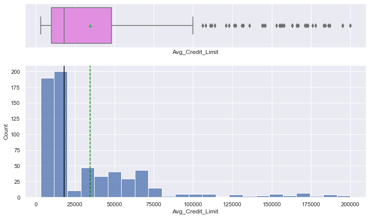

```python
# Boxplot and histogram of the Avg_Credit_Limit variable

histogram_boxplot(data = df, feature = "Avg_Credit_Limit");
```

**Observations**

- The mean is greater than the median, hence the right hand skewedness.
- There are very high average credit limits in the data, hence the outliers.
- The maximum average credit limit is 200,000.

```python
# function to create labeled barplots


def labeled_barplot(data, feature, perc=False, n=None):
    """
    Barplot with percentage at the top

    data: dataframe
    feature: dataframe column
    perc: whether to display percentages instead of count (default is False)
    n: displays the top n category levels (default is None, i.e., display all levels)
    """

    total = len(data[feature])  # length of the column
    count = data[feature].nunique()
    if n is None:
        plt.figure(figsize=(count + 1, 5))
    else:
        plt.figure(figsize=(n + 1, 5))

    plt.xticks(rotation=90, fontsize=15)
    ax = sns.countplot(
        data=data,
        x=feature,
        palette="Paired",
        order=data[feature].value_counts().index[:n].sort_values(),
    )

    for p in ax.patches:
        if perc == True:
            label = "{:.1f}%".format(
                100 * p.get_height() / total
            )  # percentage of each class of the category
        else:
            label = p.get_height()  # count of each level of the category

        x = p.get_x() + p.get_width() / 2  # width of the plot
        y = p.get_height()  # height of the plot

        ax.annotate(
            label,
            (x, y),
            ha="center",
            va="center",
            size=12,
            xytext=(0, 5),
            textcoords="offset points",
        )  # annotate the percentage

    plt.show()  # show the plot
```

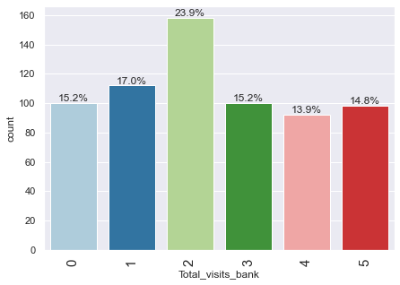

```python
# Barplot of the Total_visits_bank variable

labeled_barplot(data = df, feature = "Total_visits_bank", perc = True)
```

**Observations**

- 100 of their customers, representing 15.2% did not visit the bank atall in a year.
- The highest visit to the bank by their customers in a year is 5 and only 14.8% of them do so.
- The group of customers with 2 vists to the bank have the highest percentage of 23.9%.
- The group of customers with 4 vists to the bank have the least percentage of 13.9%.

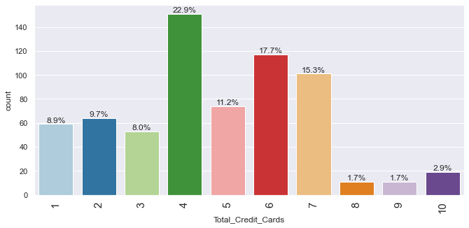

```python
# Barplot of the Total_Credit_Cards variable

labeled_barplot(data = df, feature = "Total_Credit_Cards", perc = True)
```

**Observations**

- All of their customers posess credit cards.
- 150 of their customers, representing 22.9% posess 4 number of credit cards.
- The highest number of credit cards possessed by their customers in a year is 10 and only 2.9% of them do so.
- 8.9% of them have just 1 credit card which is the minimum.
- 67.1% of their customers possess between 4 and 7 credit cards.
- 26.6% of them have 3 or less credit cards in a year.
- Just 6.3% of them have 8 or more credit cards in a year.
- The number of customers with 4 credit cards have the highest percentage (22.9%) while the customers with 8 or 9 credit cards have the least percentage (1.7%).

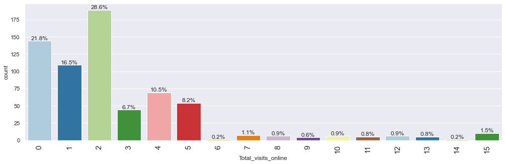

```python
# Barplot of the Total_visits_online variable

labeled_barplot(data = df, feature = "Total_visits_online", perc = True)
```

```python
# To know the number of customers and the number of online visits in a year.

df["Total_visits_online"].value_counts()
```

```
2     189
0     144
1     109
4      69
5      54
3      44
15     10
7       7
10      6
12      6
8       6
11      5
13      5
9       4
14      1
6       1
Name: Total_visits_online, dtype: int64
```

**Observations from barplot and the value_count above**

- 144 of their customers, representing 21.8%, did not visit or make online login in a year.
- The highest number of online login made in a year is 15 which was done by 10 of their customers, representing 1.5%.
- 189 of their customers, representing 28.6%, made online login twice in a year. This is the highest percentage in a year.
- 66.9% of their customers (442 customers) made online login twice or less in a year.
- Just 7.9% of their customers visited or made online login 6 times or more in a year.

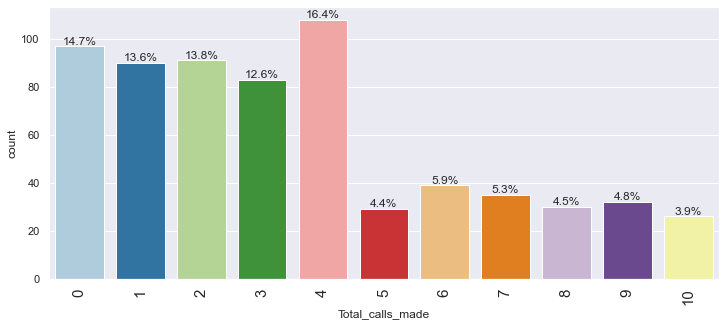

```python
# Barplot of the Total_calls_made variable

labeled_barplot(data = df, feature = "Total_calls_made", perc = True)
```

**Observations**

- The highest number of calls made to the bank in a year is 10 by 3.9% of their customers.
- The group of customers with the highest percentage (16.4%) of calls to the bank, did so 4 times in a year.
- 14.7% of their customers did not call either the bank or their customer service department at all in a year.
- 71.1% of their customers called the bank or their service customer department 4 times or less in a year.
- Only 28.9% of them called 5 times or more.

## To Treat the Outlier

```python
# To correct the outliers in the "Avg_Credit_Limit" feature

df["Avg_Credit_Limit"] = np.log(df["Avg_Credit_Limit"])

df["Avg_Credit_Limit"]
```

```
0      11.512925
1      10.819778
2      10.819778
3      10.308953
4      11.512925
         ...
655    11.502875
656    11.338572
657    11.884489
658    12.055250
659    12.025749
Name: Avg_Credit_Limit, Length: 660, dtype: float64
```

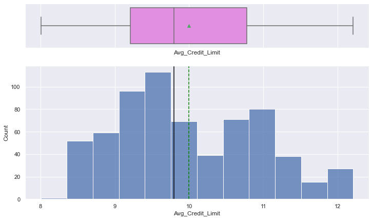

```python
# Boxplot and histogram of the corrected  "Avg_Credit_Limit" feature

histogram_boxplot(data = df, feature = "Avg_Credit_Limit");
```

- The outlier has been treated.

## Bivariates

### Correlation Plot

```python
# To know the correlation among the variables

df_mat = df.corr()
df_mat
```

|  | Sl_No | Customer Key | Avg_Credit_Limit | Total_Credit_Cards | Total_visits_bank | Total_visits_online | Total_calls_made |
| --- | --- | --- | --- | --- | --- | --- | --- |
| Sl_No | 1.000000 | 0.052886 | 0.754720 | 0.739329 | 0.406438 | 0.033916 | -0.684125 |
| Customer Key | 0.052886 | 1.000000 | 0.072692 | -0.010281 | -0.000560 | 0.022506 | 0.005968 |
| Avg_Credit_Limit | 0.754720 | 0.072692 | 1.000000 | 0.586243 | 0.073937 | 0.292976 | -0.466308 |
| Total_Credit_Cards | 0.739329 | -0.010281 | 0.586243 | 1.000000 | 0.315796 | 0.167758 | -0.651251 |
| Total_visits_bank | 0.406438 | -0.000560 | 0.073937 | 0.315796 | 1.000000 | -0.551861 | -0.506016 |
| Total_visits_online | 0.033916 | 0.022506 | 0.292976 | 0.167758 | -0.551861 | 1.000000 | 0.127299 |
| Total_calls_made | -0.684125 | 0.005968 | -0.466308 | -0.651251 | -0.506016 | 0.127299 | 1.000000 |

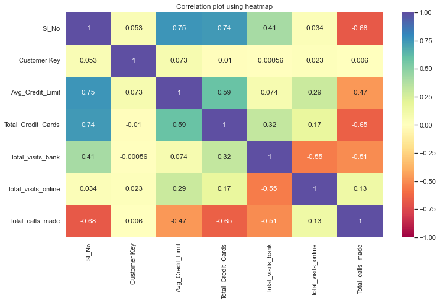

```python
# To view the corrlation using heatman

plt.figure(figsize=(12,7))
sns.heatmap(data= df_mat, annot=True, vmin =-1, vmax =1, cmap="Spectral")
plt.title("Correlation plot using heatmap")
plt.show();
```

**Observations**

# Data Pre-processing

```python
# libraries to help scale the data and cluster the data

from sklearn.preprocessing import MinMaxScaler
from sklearn.cluster import KMeans
```

### To drop the Primary key of the records (S1_No) and the customer indentification number (Customer key)

```python
# To drop the Sl_No and Customer Key variables

df = df.drop(["Sl_No", "Customer Key"], axis =1)

df
```

|  | Avg_Credit_Limit | Total_Credit_Cards | Total_visits_bank | Total_visits_online | Total_calls_made |
| --- | --- | --- | --- | --- | --- |
| 0 | 11.512925 | 2 | 1 | 1 | 0 |
| 1 | 10.819778 | 3 | 0 | 10 | 9 |
| 2 | 10.819778 | 7 | 1 | 3 | 4 |
| 3 | 10.308953 | 5 | 1 | 1 | 4 |
| 4 | 11.512925 | 6 | 0 | 12 | 3 |
| ... | ... | ... | ... | ... | ... |
| 655 | 11.502875 | 10 | 1 | 10 | 0 |
| 656 | 11.338572 | 10 | 1 | 13 | 2 |
| 657 | 11.884489 | 8 | 1 | 9 | 1 |
| 658 | 12.055250 | 10 | 1 | 15 | 0 |
| 659 | 12.025749 | 9 | 0 | 12 | 2 |

660 rows × 5 columns

**Note**

- These two variables were dropped because they will not contribute to the clustering information.

```python
# To create an instant of the scaler

scaler = MinMaxScaler()

# To calculate each variable to have a range between 0 and 1, and convert each varaible to have a range between 0 and 1

df_scaler = scaler.fit_transform(df)

# To check the transformation

df_scaler
```

```
array([[0.83495337, 0.11111111, 0.2       , 0.06666667, 0.        ],
       [0.66990674, 0.22222222, 0.        , 0.66666667, 0.9       ],
       [0.66990674, 0.66666667, 0.2       , 0.2       , 0.4       ],
       ...,
       [0.92342709, 0.77777778, 0.2       , 0.6       , 0.1       ],
       [0.96408727, 1.        , 0.2       , 1.        , 0.        ],
       [0.95706281, 0.88888889, 0.        , 0.8       , 0.2       ]])
```

```python
# Creating a datafram for the scaled data

df_scaler_df = pd.DataFrame(df_scaler, columns=df.columns)

df_scaler_df
```

|  | Avg_Credit_Limit | Total_Credit_Cards | Total_visits_bank | Total_visits_online | Total_calls_made |
| --- | --- | --- | --- | --- | --- |
| 0 | 0.834953 | 0.111111 | 0.2 | 0.066667 | 0.0 |
| 1 | 0.669907 | 0.222222 | 0.0 | 0.666667 | 0.9 |
| 2 | 0.669907 | 0.666667 | 0.2 | 0.200000 | 0.4 |
| 3 | 0.548273 | 0.444444 | 0.2 | 0.066667 | 0.4 |
| 4 | 0.834953 | 0.555556 | 0.0 | 0.800000 | 0.3 |
| ... | ... | ... | ... | ... | ... |
| 655 | 0.832560 | 1.000000 | 0.2 | 0.666667 | 0.0 |
| 656 | 0.793438 | 1.000000 | 0.2 | 0.866667 | 0.2 |
| 657 | 0.923427 | 0.777778 | 0.2 | 0.600000 | 0.1 |
| 658 | 0.964087 | 1.000000 | 0.2 | 1.000000 | 0.0 |
| 659 | 0.957063 | 0.888889 | 0.0 | 0.800000 | 0.2 |

660 rows × 5 columns

```python
# create an instance of kmeans

kmeans = KMeans(random_state=0)

# Variable to store inertia

SSE = []
for i in range(1,10):
    kmeans = KMeans(n_clusters= i)
    kmeans.fit(df_scaler)
    SSE.append(kmeans.inertia_)
```

```python
# To check the SSE

SSE
```

```
[220.15740716673977,
 121.94828125228901,
 74.69766315568424,
 58.626096293169866,
 52.31947696191807,
 46.18307829973332,
 41.2529576144335,
 38.516793813781526,
 37.0601414956858]
```

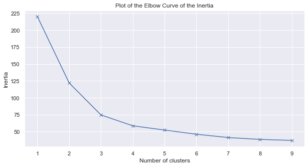

```python
# To create a dataframe with clusters and SSE as columns

frame = pd.DataFrame({"Cluster": range(1,10), "SSE": SSE})


plt.figure(figsize = (10, 5))
plt.plot(frame["Cluster"], frame["SSE"], marker = "x")
plt.title("Plot of the Elbow Curve of the Inertia")
plt.xlabel("Number of clusters")
plt.ylabel("Inertia")
plt.show()
```

- The optimal number of cluster will be 4

### To rebuild the model with the optimal number of clusters

```python
# To rebuild the model with optimal cluster

Kmeans = KMeans(n_clusters=4, random_state=0)

# To train and make prediction of the labels

pred = Kmeans.fit_predict(df_scaler)
```

```python
# To check the prediction

Kmeans_clusters = Kmeans.labels_

Kmeans_clusters
```

```
array([0, 3, 0, 0, 1, 3, 1, 0, 3, 3, 3, 3, 3, 3, 3, 3, 3, 3, 3, 3, 3, 3,
       3, 3, 3, 3, 3, 3, 3, 3, 3, 3, 3, 3, 3, 3, 3, 3, 3, 3, 3, 3, 0, 3,
       3, 3, 3, 3, 3, 3, 3, 3, 3, 3, 3, 3, 3, 3, 3, 3, 3, 3, 3, 3, 3, 3,
       3, 3, 3, 3, 3, 3, 3, 3, 3, 3, 3, 3, 3, 3, 3, 3, 3, 3, 3, 3, 3, 3,
       3, 3, 3, 3, 3, 3, 3, 3, 3, 3, 3, 3, 3, 3, 3, 3, 3, 3, 3, 3, 3, 3,
       3, 3, 3, 3, 3, 3, 3, 3, 3, 3, 3, 3, 3, 3, 3, 3, 3, 3, 3, 3, 3, 3,
       3, 3, 3, 3, 3, 3, 3, 3, 3, 3, 3, 3, 3, 3, 3, 3, 3, 3, 3, 3, 3, 3,
       3, 3, 3, 3, 3, 3, 3, 3, 3, 3, 3, 3, 3, 3, 3, 3, 3, 3, 3, 3, 3, 3,
       3, 3, 3, 3, 3, 3, 3, 3, 3, 3, 3, 3, 3, 3, 3, 3, 3, 3, 3, 3, 3, 3,
       3, 3, 3, 3, 3, 3, 3, 3, 3, 0, 3, 3, 3, 3, 3, 3, 3, 3, 3, 3, 3, 3,
       3, 3, 3, 3, 3, 3, 3, 3, 0, 0, 2, 0, 2, 0, 2, 2, 2, 2, 0, 0, 0, 2,
       0, 2, 0, 0, 2, 0, 2, 2, 0, 0, 2, 0, 0, 2, 0, 2, 0, 2, 2, 0, 2, 0,
       2, 2, 2, 2, 2, 2, 2, 0, 0, 2, 2, 0, 2, 2, 2, 2, 2, 0, 0, 0, 0, 2,
       2, 0, 0, 2, 0, 0, 0, 0, 2, 2, 2, 2, 2, 2, 2, 2, 0, 2, 2, 2, 0, 0,
       2, 2, 2, 0, 0, 0, 0, 0, 2, 2, 2, 0, 2, 2, 0, 0, 2, 2, 2, 2, 2, 2,
       0, 2, 0, 2, 2, 2, 2, 0, 0, 0, 0, 0, 2, 0, 0, 2, 0, 0, 2, 0, 0, 0,
       0, 2, 2, 2, 2, 2, 0, 0, 0, 0, 2, 0, 2, 2, 2, 0, 0, 2, 0, 0, 2, 2,
       2, 0, 2, 0, 2, 0, 0, 0, 0, 0, 2, 2, 0, 0, 2, 2, 0, 2, 2, 0, 2, 2,
       2, 0, 0, 0, 0, 2, 0, 0, 0, 0, 0, 2, 0, 0, 0, 2, 2, 2, 0, 0, 0, 2,
       0, 2, 0, 2, 0, 0, 2, 0, 0, 2, 2, 2, 2, 2, 0, 0, 0, 2, 0, 0, 0, 2,
       0, 0, 0, 2, 2, 2, 2, 0, 2, 0, 0, 2, 2, 2, 0, 0, 2, 0, 0, 2, 2, 2,
       2, 2, 0, 2, 0, 2, 2, 0, 2, 0, 0, 0, 0, 2, 2, 2, 0, 0, 0, 0, 0, 2,
       2, 0, 0, 2, 2, 2, 0, 2, 2, 0, 0, 0, 0, 0, 2, 2, 2, 0, 0, 0, 2, 0,
       2, 0, 0, 2, 0, 0, 0, 0, 0, 2, 2, 0, 2, 0, 2, 0, 2, 0, 0, 2, 0, 0,
       0, 0, 0, 0, 0, 0, 2, 2, 2, 0, 2, 2, 0, 2, 2, 0, 0, 2, 0, 2, 0, 2,
       2, 0, 0, 2, 0, 2, 2, 2, 2, 2, 0, 2, 0, 2, 2, 2, 2, 0, 2, 2, 0, 0,
       2, 0, 0, 0, 0, 0, 2, 0, 2, 2, 2, 0, 2, 2, 0, 0, 0, 2, 0, 0, 2, 2,
       0, 2, 2, 2, 2, 0, 2, 2, 2, 0, 0, 0, 0, 0, 2, 0, 0, 2, 1, 1, 1, 1,
       1, 1, 1, 1, 1, 1, 1, 1, 1, 1, 1, 1, 1, 1, 1, 1, 1, 1, 1, 1, 1, 1,
       1, 1, 1, 1, 1, 1, 1, 1, 1, 1, 1, 1, 1, 1, 1, 1, 1, 1, 1, 1, 1, 1])
```

```python
# Library to help calculate the sihouette score

from sklearn.metrics import silhouette_score

# To calculate the silhouette score

Kmeans.sil = silhouette_score(df_scaler, pred)

Kmeans.sil
```

```
0.3753717656533214
```

**Interpretation of silhouette score**

- The silhouette score of 0.3754 obtained is a positive value which means that the data sample (or the information in the data) has been matched or assigned to the appropriate cluster.

```python
# To add the kmeans clusters to the original and scaled dataframes

df["Kmeans_clusters"] = Kmeans_clusters
```

```python
# To list the columns in the data after the addition

nul_col = df_scaler_df.columns.tolist()

nul_col
```

```
['Avg_Credit_Limit',
 'Total_Credit_Cards',
 'Total_visits_bank',
 'Total_visits_online',
 'Total_calls_made']
```

### Plot of the variables conditioned on the kmeans clusters

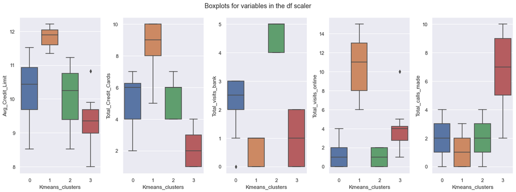

```python
# Plot of the variables conditioned on the kmeans_clusters

fig, ax = plt.subplots(1, 5, figsize = (16, 6))
fig.suptitle("Boxplots for variables in the df scaler")

count = 0
for i in range(5):
    sns.boxplot(ax =ax[i], x = df["Kmeans_clusters"], y = df[nul_col[count]])
    count +=1
fig.tight_layout()
```

**Observations**

### from the Avg_credit_Limit boxplot

- Cluster 1 has the highest average credit limit, followed by cluster 0
- Cluster 3 has the least average credit limit in a year.

### from the Total_credit_cards boxplot

- Cluser 1 has the highest number of credit cards in a year with an average of 9 credit cards
- Cluster 0 has the second highest of credit cards with average of 6.
- Cluster 3 has the least wth an average of 2 credit cards in a year..

### from the Total_visit_bank boxplot

- Cluster 2 has the highest number of visits to the bank in a year with 75% of them making 5 visits, and followed by cluster 0.
- Cluster 1 made the least visit in a year with 75% of the customers in this cluster making just 1 visit to the bank while 25% did not make any visit atall.

### from the Total_online_visit boxplot

- Cluster 1 has the highest number of online visit or login in a year with an average of 11 visits, followed by cluster 3.
- Clusters 0 and 2 made the least online logins with an average of 1 online visit in a year. 75% of these customers made just 2 visits while 25% of them did not make any online visit or login.

### from the Total_calls_made boxplot

- Cluster 3 made the most calls with an average of 7 calls in a year.
- Clusters 0 and 2 made an average calls of 2 to the bank or their customer service department in a year.
- Cluster 1 made the least calls with an average of 1 call in a year. 25% of the customers in this cluster did not make any call to the bank atall throughout the year while 75% of them only made 2 calls.

# DBSCAN

```python
# Libraries to help build the model

from sklearn.cluster import DBSCAN
import itertools
```

```python
# To instantiate the model with eps = 0.3 and min_samples = 6

dbscan = DBSCAN(eps =0.3, min_samples=6)

# To train the model

db_labels = dbscan.fit_predict(df_scaler)
```

```python
# To check the dbscan labels

db_labels
```

```
array([-1, -1,  0,  0,  1,  0,  1, -1,  0,  0,  0,  0,  0,  0,  0,  0,  0,
        0,  0,  0,  0,  0,  0,  0,  0,  0,  0,  0,  0,  0,  0,  0,  0,  0,
        0,  0,  0,  0,  0,  0,  0,  0,  0,  0,  0,  0,  0,  0,  0,  0,  0,
        0,  0,  0,  0,  0,  0,  0,  0,  0,  0,  0,  0,  0,  0,  0,  0,  0,
        0,  0,  0,  0,  0,  0,  0,  0,  0,  0,  0,  0,  0,  0,  0,  0,  0,
        0,  0,  0,  0,  0,  0,  0,  0,  0,  0,  0,  0,  0,  0,  0,  0,  0,
        0,  0,  0,  0,  0,  0,  0,  0,  0,  0,  0,  0,  0,  0,  0,  0,  0,
        0,  0,  0,  0,  0,  0,  0,  0,  0,  0,  0,  0,  0,  0,  0,  0,  0,
        0,  0,  0,  0,  0,  0,  0,  0,  0,  0,  0,  0,  0,  0,  0,  0,  0,
        0,  0,  0,  0,  0,  0,  0,  0,  0,  0,  0,  0,  0,  0,  0,  0,  0,
        0,  0,  0,  0,  0,  0,  0,  0,  0,  0,  0,  0,  0,  0,  0,  0,  0,
        0,  0,  0,  0,  0,  0,  0,  0,  0,  0,  0,  0,  0,  0,  0,  0,  0,
        0,  0,  0,  0,  0,  0,  0,  0,  0,  0,  0,  0,  0,  0,  0,  0,  0,
        0,  0,  0,  0,  0,  0,  0,  0,  0,  0,  0,  0,  0,  0,  0,  0,  0,
        0,  0,  0,  0,  0,  0,  0,  0,  0,  0,  0,  0,  0,  0,  0,  0,  0,
```

[output cut: 25 more lines]

```python
# add dbscan label to the original data

df["db_clusters"] = db_labels
```

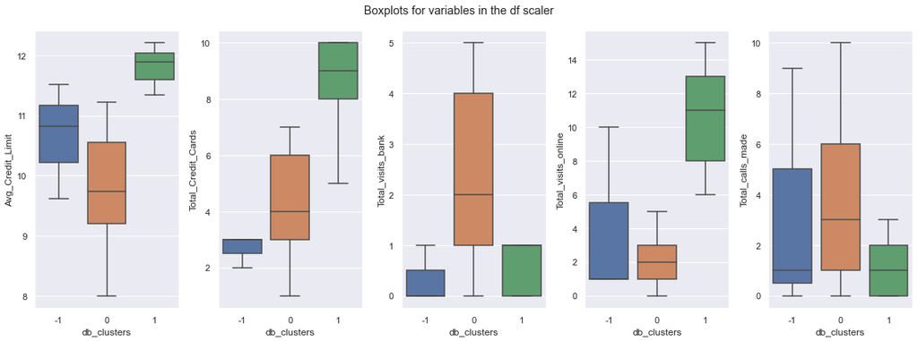

```python
# Plot of the variables conditioned on the kmeans_clusters

fig, ax = plt.subplots(1, 5, figsize = (16, 6))
fig.suptitle("Boxplots for variables in the df scaler")

count = 0
for i in range(5):
    sns.boxplot(ax =ax[i], x = df["db_clusters"], y = df[nul_col[count]])
    count +=1
fig.tight_layout()
```

**Observations**

- Clusters -1 are the noisy samples in the data as clssified by DBSCAN.
- The customers in the cluster 1 have the highest average credit limit, total credit cards and total visit online but least total calls made.
- The customers in cluster 0 have the highest number of visits to the bank and the total calls made on average but the least in the total visit online and average credit limit.

# Recommendations from the Observations noted

### Obs

- From the 4 clusters formed using optimal number in Kmeans, the cluster 1 with the highest average credit limit also has the highest number of credit cards, and the highest number of online login or visits. This cluster made the least number of visits to the bank and also has the least number of calls to the bank or their customer service department in a year.

### Recom

- This is the ideal set of customers. the bank will want all their customers to be in this cluster. They have credit cards and they use them, hence the high average credit limits. They transact more online, thereby helping the bank to reduce the cost of physical service and unnecessary queues in the bank.

### Obs

- The customers in cluster 3 have the least average credit limit and the least number of credit cards but have the highest number of calls to the bank in a year.

### Recom

- This set of customers may have little or no education/orientation about the credit cards and their uses or see no benefits in them. They may believe more in the traditional banking. Selling the benefits of credit cards and online banking to them can turn many of them to the cluster-1-type of customers.

### Obs

- Cluster 0 is ranked second in the average credit limit, total credit card and the total visit to the bank but least in the total online login and second to the last in the total calls made in a year.

### Recom

- This set of the customers believes or uses mostly one banking product (credit cards) than others. Engaging them to show them how the online banking works will convince them. Little effort will turn them to both credit cards and online banking customers.

### Obs

- The customers in cluster 2 have the highest number of visits to the bank but least number of online visits and of second to the least in the total calls made to the bank, the average credit limit and the total credit cards.

### Recom

- This is the traditional banking method. They do prefer physical transactions to online banking. They maybe the older customers who do not believe much in the online banking. If encouraged, they can be easily moved to the online banking to reduce the cost and time of servicing these customers physically.